# Machine learning Probabilistico

Leonardo Rubio y Angela Villate

27/10/2020

## Parcial Machine learning Probabilistico

Cargamos la data que describe datos laborales de empleados de una f?brica. Contamos con informaci?n de caracterizaci?n e informaci?n laboral: fecha de ingreso, retiro, salario. El modelo se propone, a aprtir de estos datos generar el pron?stico del retiro de los empleados.

```r
library(readxl)
df_empleados <- read_excel ("C:/Users/ASUS/Downloads/df_empleados.xlsx")
head(df_empleados)
```

```
## # A tibble: 6 x 26
##   Fecha               `Codigo empresa` `ID Genero` `ID Estado civi~
##   <dttm>                         <dbl> <chr>       <chr>
## 1 2017-12-31 00:00:00               21 M           ND
## 2 2017-12-31 00:00:00               21 M           ND
## 3 2017-12-31 00:00:00               21 M           ND
## 4 2017-12-31 00:00:00               21 M           ND
## 5 2017-12-31 00:00:00               21 M           ND
## 6 2017-12-31 00:00:00               21 M           ND
## # ... with 22 more variables: `Fecha nacimiento` <dttm>, `Codigo
## #   localidad` <dbl>, `Tipo nomina` <chr>, `Fecha ingreso` <dttm>, `Fecha
## #   inicio contrato` <dttm>, `ID Cargo` <dbl>, `Tipo cargo` <chr>, `Nivel
## #   cargo` <dbl>, `Categoria cargo` <dbl>, `Tipo area` <chr>, `ID Centro
## #   costo` <dbl>, `Señal sindicalizado` <chr>, `Clase empleado` <chr>, `Clase
## #   nomina` <dbl>, `Subsidio transporte` <chr>, `Porcentaje riesgo` <dbl>,
## #   Salario <chr>, `Compensación variable` <chr>, `Porcent comp
## #   variable` <chr>, `Total salario` <dbl>, Cedula_anonimizada <dbl>,
## #   Ubicacion_anonimizada <dbl>
```

- Descripción del proceso de recategorización (datos faltantes a NS/NR, unificación de categorías, transformaciones de variables entre otras).

Realizamos la limpieza de los datos: en este paso se revisaron los datos, se identificaron los espacios vac?os y se les asign? una categor?a. As? mismo se estandarizaron los valores para poder tener una lectura m?s clara.

```r
#library(plyr)
#library(h2o)
#revalue(df_empleados$`ID Estado civil`, c(`0` = "ND", `NO DEFINIDO` = "ND"))
df_empleados$`ID Estado civil`[df_empleados$`ID Estado civil` == "0"] = "ND"
df_empleados$`ID Estado civil`[df_empleados$`ID Estado civil` == "NO DEFINIDO"] = "ND"
df_empleados$`ID Estado civil`[df_empleados$`ID Estado civil` == "CASADO"] = "CAS"
df_empleados$`ID Estado civil`[df_empleados$`ID Estado civil` == "DIVORCIADO"] = "DIV"
df_empleados$`ID Estado civil`[df_empleados$`ID Estado civil` == "SEPARADO"] = "SEP"
df_empleados$`ID Estado civil`[df_empleados$`ID Estado civil` == "SOLTERO"] = "SOL"
df_empleados$`ID Estado civil`[df_empleados$`ID Estado civil` == "UNION LIBRE"] = "UNI"
df_empleados$`ID Estado civil`[df_empleados$`ID Estado civil` == "VIUDO"] = "VIU"
```

```r
df_empleados$ano_nacimiento <-as.integer(format(df_empleados$`Fecha nacimiento`, "%Y"))
df_empleados$ano_ingreso <-as.integer(format(df_empleados$`Fecha ingreso`, "%Y"))
```

Aqu? contamos con una visualizaci?n delos datos estandarizados.

```r
head(df_empleados)
```

```
## # A tibble: 6 x 28
##   Fecha               `Codigo empresa` `ID Genero` `ID Estado civi~
##   <dttm>                         <dbl> <chr>       <chr>
## 1 2017-12-31 00:00:00               21 M           ND
## 2 2017-12-31 00:00:00               21 M           ND
## 3 2017-12-31 00:00:00               21 M           ND
## 4 2017-12-31 00:00:00               21 M           ND
## 5 2017-12-31 00:00:00               21 M           ND
## 6 2017-12-31 00:00:00               21 M           ND
## # ... with 24 more variables: `Fecha nacimiento` <dttm>, `Codigo
## #   localidad` <dbl>, `Tipo nomina` <chr>, `Fecha ingreso` <dttm>, `Fecha
## #   inicio contrato` <dttm>, `ID Cargo` <dbl>, `Tipo cargo` <chr>, `Nivel
## #   cargo` <dbl>, `Categoria cargo` <dbl>, `Tipo area` <chr>, `ID Centro
## #   costo` <dbl>, `Señal sindicalizado` <chr>, `Clase empleado` <chr>, `Clase
## #   nomina` <dbl>, `Subsidio transporte` <chr>, `Porcentaje riesgo` <dbl>,
## #   Salario <chr>, `Compensación variable` <chr>, `Porcent comp
## #   variable` <chr>, `Total salario` <dbl>, Cedula_anonimizada <dbl>,
## #   Ubicacion_anonimizada <dbl>, ano_nacimiento <int>, ano_ingreso <int>
```

Realizaremos una limpieza de los datos, quitando los campos vacios y los que se creen son poco significantes en el modelo.

- Exclusiones del tipo de retiro: Decidimos no realizar ninguna exlucion por que todos los tipos retiros nos parecieron significativos,

Cargamos los daos de los retiros de los empleados

```r
library(readxl)
df_retiros <- read_excel("C:/Users/ASUS/Downloads/df_retiros.xlsx")
head(df_retiros)
```

```
## # A tibble: 6 x 5
##   `FECHA FIN CONTRATO` `CAUSA NOMBRE`   `TIPO DE RETIRO` retiro Cedula_anonimiz~
##   <dttm>               <chr>            <chr>             <dbl>            <dbl>
## 1 2017-01-01 00:00:00  MUTUO ACUERDO    DESEADO               1             1218
## 2 2017-01-01 00:00:00  RENUNCIA VOLUNT~ NO DESEADO            1             1484
## 3 2017-01-03 00:00:00  RENUNCIA VOLUNT~ NO DESEADO            1             1100
## 4 2017-01-05 00:00:00  RENUNCIA VOLUNT~ NO DESEADO            1              806
## 5 2017-01-10 00:00:00  RENUNCIA VOLUNT~ NO DESEADO            1              226
## 6 2017-01-12 00:00:00  RENUNCIA VOLUNT~ NO DESEADO            1              249
```

Verificamos los datos de retiros repetidos para evitar sesgos o sobreajustes en el modelo.

```r
library("dplyr")          ## load
repetidos <-  df_retiros %>%
group_by(Cedula_anonimizada) %>%
summarize(retiro = sum(retiro, na.rm = TRUE)) %>%
filter(!is.na(retiro))

repetidos %>% select(Cedula_anonimizada,retiro) %>%
             filter(retiro > 1 )
```

```
## # A tibble: 3 x 2
##   Cedula_anonimizada retiro
##                <dbl>  <dbl>
## 1               1069      2
## 2               1098      2
## 3               1299      2
```

```r
df_retiros$ano_fin_contrato <-as.integer(format(df_retiros$`FECHA FIN CONTRATO`, "%Y"))
```

- Descripción de la integración de las fuentes de información Establecemos la union de las dos bases: la de retiros y c?dulas anonimizadas.

```r
datos_join1 <- right_join(df_retiros, df_empleados ,by = "Cedula_anonimizada")
head(datos_join1)
```

```
## # A tibble: 6 x 33
##   `FECHA FIN CONTRAT~ `CAUSA NOMBRE` `TIPO DE RETIRO` retiro Cedula_anonimiz~
##   <dttm>              <chr>          <chr>             <dbl>            <dbl>
## 1 NA                  <NA>           <NA>                 NA             1531
## 2 NA                  <NA>           <NA>                 NA              442
## 3 NA                  <NA>           <NA>                 NA             1644
## 4 2020-07-03 00:00:00 FALLECIMIENTO  No Deseada            1             1942
## 5 NA                  <NA>           <NA>                 NA             1914
## 6 NA                  <NA>           <NA>                 NA             1862
## # ... with 28 more variables: ano_fin_contrato <int>, Fecha <dttm>, `Codigo
## #   empresa` <dbl>, `ID Genero` <chr>, `ID Estado civil` <chr>, `Fecha
## #   nacimiento` <dttm>, `Codigo localidad` <dbl>, `Tipo nomina` <chr>, `Fecha
## #   ingreso` <dttm>, `Fecha inicio contrato` <dttm>, `ID Cargo` <dbl>, `Tipo
## #   cargo` <chr>, `Nivel cargo` <dbl>, `Categoria cargo` <dbl>, `Tipo
## #   area` <chr>, `ID Centro costo` <dbl>, `Señal sindicalizado` <chr>, `Clase
## #   empleado` <chr>, `Clase nomina` <dbl>, `Subsidio transporte` <chr>,
## #   `Porcentaje riesgo` <dbl>, Salario <chr>, `Compensación variable` <chr>,
## #   `Porcent comp variable` <chr>, `Total salario` <dbl>,
## #   Ubicacion_anonimizada <dbl>, ano_nacimiento <int>, ano_ingreso <int>
```

```r
datos_join1$retiro[is.na(datos_join1$retiro) ] = 0
datos_join1$ano_fin_contrato[is.na(datos_join1$ano_fin_contrato) ] = 2020

#datos_join1$retiro <- datos_join1$retiro %>% replace_na(0)
#datos_join1$retiro <- revalue(datos_join1$retiro, c(NA=0))
head(datos_join1)
```

```
## # A tibble: 6 x 33
##   `FECHA FIN CONTRAT~ `CAUSA NOMBRE` `TIPO DE RETIRO` retiro Cedula_anonimiz~
##   <dttm>              <chr>          <chr>             <dbl>            <dbl>
## 1 NA                  <NA>           <NA>                  0             1531
## 2 NA                  <NA>           <NA>                  0              442
## 3 NA                  <NA>           <NA>                  0             1644
## 4 2020-07-03 00:00:00 FALLECIMIENTO  No Deseada            1             1942
## 5 NA                  <NA>           <NA>                  0             1914
## 6 NA                  <NA>           <NA>                  0             1862
## # ... with 28 more variables: ano_fin_contrato <dbl>, Fecha <dttm>, `Codigo
## #   empresa` <dbl>, `ID Genero` <chr>, `ID Estado civil` <chr>, `Fecha
## #   nacimiento` <dttm>, `Codigo localidad` <dbl>, `Tipo nomina` <chr>, `Fecha
## #   ingreso` <dttm>, `Fecha inicio contrato` <dttm>, `ID Cargo` <dbl>, `Tipo
## #   cargo` <chr>, `Nivel cargo` <dbl>, `Categoria cargo` <dbl>, `Tipo
## #   area` <chr>, `ID Centro costo` <dbl>, `Señal sindicalizado` <chr>, `Clase
## #   empleado` <chr>, `Clase nomina` <dbl>, `Subsidio transporte` <chr>,
## #   `Porcentaje riesgo` <dbl>, Salario <chr>, `Compensación variable` <chr>,
## #   `Porcent comp variable` <chr>, `Total salario` <dbl>,
## #   Ubicacion_anonimizada <dbl>, ano_nacimiento <int>, ano_ingreso <int>
```

- Detalle de la agregación a nivel de individuo

Ahora, generamos la agrupacion de los empleados con las categorias seleccionadas para la construcci?n del modelo predictivo. Para contar coun un solo registro por empleado, se agruparon las variables que se describen en el siguiente chunk, segun el criterio de cedulas anonimizadas

```r
data_agrupada <- datos_join1 %>% group_by(Cedula_anonimizada) %>%
  summarise(
            fecha_maxima = max(Fecha),
            causa_max=max(`CAUSA NOMBRE`),
            tipo_retiro_max = max(`TIPO DE RETIRO`) ,
            fecha_fin_max=max(`FECHA FIN CONTRATO`),
            retiro_max = max(retiro), genero_max = max(`ID Genero`) ,
            estado_civil_max = max(`ID Estado civil`),
            cargo_count = max(`Tipo cargo`),
            nivel_max = max(`Nivel cargo`),
            area_max= max(`Tipo area`),
            salario_max = max(`Total salario`),
            salario_min = min(`Total salario`),
            ano_nacimiento = max(ano_nacimiento),
            ano_ingreso   = max(ano_ingreso),
            ano_fin_contrato = max(ano_fin_contrato),
            conteo_nomina = n())
head(data_agrupada)
```

```
## # A tibble: 6 x 17
##   Cedula_anonimiz~ fecha_maxima        causa_max tipo_retiro_max
##              <dbl> <dttm>              <chr>     <chr>
## 1                1 2020-08-31 00:00:00 RETIRO V~ No Deseada
## 2                2 2020-12-31 00:00:00 VENCIMIE~ NO APLICA
## 3                3 2020-12-31 00:00:00 VENCIMIE~ NO APLICA
## 4                4 2020-08-31 00:00:00 <NA>      <NA>
## 5                5 2020-08-31 00:00:00 VENCIMIE~ No Deseada
## 6                6 2020-12-31 00:00:00 VENCIMIE~ NO APLICA
## # ... with 13 more variables: fecha_fin_max <dttm>, retiro_max <dbl>,
## #   genero_max <chr>, estado_civil_max <chr>, cargo_count <chr>,
## #   nivel_max <dbl>, area_max <chr>, salario_max <dbl>, salario_min <dbl>,
## #   ano_nacimiento <dbl>, ano_ingreso <dbl>, ano_fin_contrato <dbl>,
## #   conteo_nomina <int>
```

```r
data_agrupada$anos_trabajados <- (data_agrupada$ano_fin_contrato - data_agrupada$ano_ingreso)
data_agrupada$anos_ingreso  <- (data_agrupada$ano_ingreso - data_agrupada$ano_nacimiento)
data_agrupada$dif_salario  <- (data_agrupada$salario_max - data_agrupada$salario_min)

data_agrupada$anos_trabajados[is.na(data_agrupada$anos_trabajados) ] = round((data_agrupada$conteo_nomina / 12),0)
data_agrupada$anos_ingreso[is.na(data_agrupada$anos_ingreso) ] = 20
```

```r
data_modelo <-   data_agrupada %>% select (retiro_max, genero_max,estado_civil_max,conteo_nomina,anos_trabajados,anos_ingreso,dif_salario, Cedula_anonimizada)
data_modelo$genero_max[is.na(data_modelo$genero_max) ] = "ND"
data_modelo$estado_civil_max[is.na(data_modelo$estado_civil_max) ] = "ND"
head(data_modelo)
```

```
## # A tibble: 6 x 8
##   retiro_max genero_max estado_civil_max conteo_nomina anos_trabajados
##        <dbl> <chr>      <chr>                    <int>           <dbl>
## 1          1 M          SOL                          4               0
## 2          1 ND         SOL                          7               1
## 3          1 ND         SOL                          7               0
## 4          0 F          ND                           7               1
## 5          1 F          ND                           7               1
## 6          1 ND         SOL                          7               0
## # ... with 3 more variables: anos_ingreso <dbl>, dif_salario <dbl>,
## #   Cedula_anonimizada <dbl>
```

```r
data_modelo
```

```
## # A tibble: 1,872 x 8
##    retiro_max genero_max estado_civil_max conteo_nomina anos_trabajados
##         <dbl> <chr>      <chr>                    <int>           <dbl>
##  1          1 M          SOL                          4               0
##  2          1 ND         SOL                          7               1
##  3          1 ND         SOL                          7               0
##  4          0 F          ND                           7               1
##  5          1 F          ND                           7               1
##  6          1 ND         SOL                          7               0
##  7          0 F          SOL                          4               1
##  8          0 M          SOL                          1               0
##  9          1 ND         ND                          14               1
## 10          0 M          SOL                          4               1
## # ... with 1,862 more rows, and 3 more variables: anos_ingreso <dbl>,
## #   dif_salario <dbl>, Cedula_anonimizada <dbl>
```

## Regresion

- Justificación de los porcentajes utilizados para la muestra “train” y “test” Como modelo hemos seleccionado el de regresi?n. Para eso, particionamos la data en entrenamiento y el testeo: “variables train y test”. La particion se realizo en una proporcion del 30% y 70% debido a que es una practica frecuente.

```r
indica_train <- sample(nrow(data_modelo), round(0.7 * nrow(data_modelo)))
train <- data_modelo[indica_train,]
test <- data_modelo[-indica_train,]
```

- Análisis básico del balanceo de las variables Por considerarse buena pr?ctica, verificamos el balanceo de las muestras, con eso continuamos verificando que los datos con los que estamos trabajando sean indicativos al momento de hacer la predicci?n.

```r
train %>% group_by(retiro_max) %>%  summarise(conteo = n())
```

```
## # A tibble: 2 x 2
##   retiro_max conteo
##        <dbl>  <int>
## 1          0    947
## 2          1    363
```

```r
test %>% group_by(retiro_max) %>%  summarise(conteo = n())
```

```
## # A tibble: 2 x 2
##   retiro_max conteo
##        <dbl>  <int>
## 1          0    387
## 2          1    175
```

Teniendo los datos agrupados y depurados realizaremos los modelos

2. Justificación desde el punto de vista de la elección de las variables predictoras. Decidimos que las variables que nos permitirian hacer el modelo predictor, son aquellas que nos brindan información sobre la evolucion que ha tenido el trabajador en la compañia: Años que se llevan trabajando, comparativo de los pagos y edad al momento del ingreso a la compañia. Consideramos que son relevantes por que nos permiten hacer un análisis histórico de cada trabajador y de este modo no generar comparaciones ineficientes.

```r
head(data_modelo)
```

```
## # A tibble: 6 x 8
##   retiro_max genero_max estado_civil_max conteo_nomina anos_trabajados
##        <dbl> <chr>      <chr>                    <int>           <dbl>
## 1          1 M          SOL                          4               0
## 2          1 ND         SOL                          7               1
## 3          1 ND         SOL                          7               0
## 4          0 F          ND                           7               1
## 5          1 F          ND                           7               1
## 6          1 ND         SOL                          7               0
## # ... with 3 more variables: anos_ingreso <dbl>, dif_salario <dbl>,
## #   Cedula_anonimizada <dbl>
```

```r
M1 <- glm(retiro_max ~ (conteo_nomina + anos_trabajados + anos_ingreso + dif_salario) * (genero_max + estado_civil_max) ,data = train, family = "gaussian")
# Clasificar en setosa si probs >= 0,5
```

3. Visualizaciones, tablas de frecuencias y estadísticas que permitan evidenciar de las variables candidatas cuales están altamente asociadas con la variable target. Para tener una visualizacion mas completa del comportamiento y la relacion de los datos seleccionados para el modelo, desarrollamos una matriz de correlacion,(para las variables numericas) y tablas de frecuencia para las variables categoricas.

```r
data_modelo[is.na(data_modelo)] <- 0
correlacion<-data_modelo %>% select(retiro_max,conteo_nomina,anos_trabajados,anos_ingreso,dif_salario)
cor(correlacion)
```

```
##                 retiro_max conteo_nomina anos_trabajados anos_ingreso
## retiro_max       1.0000000   -0.51193234      0.20694504    0.5273483
## conteo_nomina   -0.5119323    1.00000000     -0.05884474   -0.3591024
## anos_trabajados  0.2069450   -0.05884474      1.00000000    0.1927143
## anos_ingreso     0.5273483   -0.35910240      0.19271431    1.0000000
## dif_salario     -0.2066798    0.23715928     -0.05439625   -0.1349196
##                 dif_salario
## retiro_max      -0.20667979
## conteo_nomina    0.23715928
## anos_trabajados -0.05439625
## anos_ingreso    -0.13491959
## dif_salario      1.00000000
```

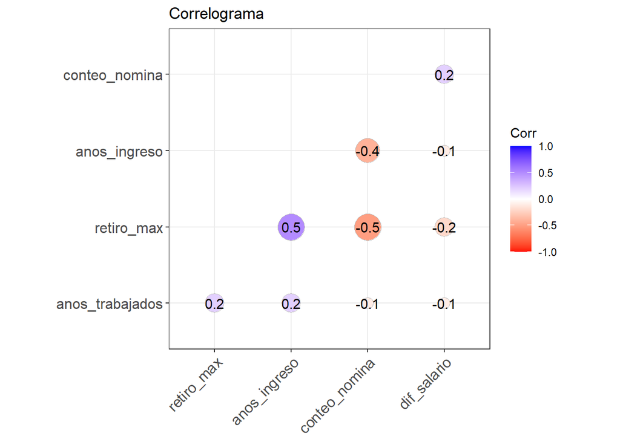

```r
library(ggcorrplot)
corr <- round(cor(correlacion), 1)
ggcorrplot(corr, hc.order = TRUE,
           type = "lower",
           lab = TRUE,
           lab_size = 4,
           method="circle",
           colors = c("red", "white", "blue"),
           title="Correlograma",
           ggtheme=theme_bw)
```

```r
tabla2=table(data_modelo$genero_max, data_modelo$estado_civil_max)
tabla2
```

```
##
##       CAS  DIV   ND  SEP  SOL  UNI  VIU
##   F    24    2   76    2  185   21    0
##   M    37    1  106    0  158   41    1
##   ND    5    0 1136    0   59   17    1
```

```r
#correlacion$genero_max
#correlacion$estado_civil_max
```

A continuaci?n generamos la matriz de confusi?n del modelo, en la que podemos ver la forma en la que clasifica los datos: verdaderos postitivos, verdaderos negativos, falsos positivos y falsos negativos. Por lo que nos muestra el modelo podemos concluir que hay un ajuste entre la sensibilidad, precisi?n y exactitud.

```r
test$probs <- predict(M1, test, type = "response")
test$yhat <- ifelse(test$probs >= 0.5, 1, 0)
table(test$retiro_max, test$yhat)
```

```
##
##       0   1
##   0 374  13
##   1  42 133
```

```r
mc <- table(test$retiro_max, test$yhat)
```

A continuaci?n, podemos observar el accuracy del modelo

```r
sum(diag(mc)) / sum(mc) # Accuracy
```

```
## [1] 0.9021352
```

• Evaluación del modelo con la muestra test. (En caso de no hacer validación cruzada) Nota: es deseable realizar validar cruzada para cuantificar las métricas y brindará un bono en el parcial de 1 punto

La validacion cruzada no fue posible debido a que intuimos que no es para modelos de regresion, sin embargo presentamos la propuesta de validacion cruzada.

```r
# validación cruzada
library("rpart")
library("rpart.plot")
library(rsample)
library(tidymodels)
set.seed(1234)
cv_folds <- vfold_cv(
  data    = train,
  v       = 5,
  repeats = 10,
  strata  = retiro_max)
#
#validacion_fit <- fit_resamples(
#  object       = M1,
  # El objeto recipe no tiene que estar entrenado
#  preprocessor = recipe( formula = retiro_max ~ ., data =  train),
#  resamples    = cv_folds,
   #metrics      = metric_set(roc_auc, pr_auc, accuracy),
#  metrics      = metric_set(rmse),
#  control      = control_resamples(save_pred = TRUE)
#)

#M1 <- glm(retiro_max ~ (conteo_nomina + anos_trabajados + anos_ingreso + dif_salario) * (genero_max + estado_civil_max) ,data = train, family = "gaussian")

#validacion_fit

#validacion_fit %>% collect_metrics(summarize = TRUE)
```

En este paso generamos los datos del pron?stico.

```r
test$probs=round(test$probs, 3)
pronosticos <- test %>% select(Cedula_anonimizada,retiro_max,probs,yhat)
head(pronosticos)
```

```
## # A tibble: 6 x 4
##   Cedula_anonimizada retiro_max probs  yhat
##                <dbl>      <dbl> <dbl> <dbl>
## 1                 12          0 0.325     0
## 2                 13          0 0.196     0
## 3                 15          1 0.375     0
## 4                 16          1 0.284     0
## 5                 20          0 0.505     1
## 6                 21          1 0.987     1
```

```r
summary(datos_join1)
```

```
##  FECHA FIN CONTRATO            CAUSA NOMBRE       TIPO DE RETIRO
##  Min.   :2017-07-15 00:00:00   Length:40864       Length:40864
##  1st Qu.:2019-02-25 00:00:00   Class :character   Class :character
##  Median :2019-08-30 00:00:00   Mode  :character   Mode  :character
##  Mean   :2019-08-12 11:01:02
##  3rd Qu.:2020-01-24 00:00:00
##  Max.   :2020-08-31 00:00:00
##  NA's   :34551
##      retiro       Cedula_anonimizada ano_fin_contrato
##  Min.   :0.0000   Min.   :   1       Min.   :2017
##  1st Qu.:0.0000   1st Qu.: 664       1st Qu.:2020
##  Median :0.0000   Median :1198       Median :2020
##  Mean   :0.1545   Mean   :1137       Mean   :2020
##  3rd Qu.:0.0000   3rd Qu.:1619       3rd Qu.:2020
##  Max.   :1.0000   Max.   :2037       Max.   :2020
##
##      Fecha                     Codigo empresa   ID Genero
##  Min.   :2017-12-31 00:00:00   Min.   :21.00   Length:40864
##  1st Qu.:2018-08-31 00:00:00   1st Qu.:21.00   Class :character
##  Median :2019-05-31 00:00:00   Median :21.00   Mode  :character
##  Mean   :2019-05-24 22:41:37   Mean   :23.78
##  3rd Qu.:2020-01-31 00:00:00   3rd Qu.:21.00
##  Max.   :2020-12-31 00:00:00   Max.   :41.00
##
##  ID Estado civil    Fecha nacimiento              Codigo localidad
##  Length:40864       Min.   :1900-01-02 00:00:00   Min.   :   0
##  Class :character   1st Qu.:1972-02-04 00:00:00   1st Qu.:1502
##  Mode  :character   Median :1983-11-04 00:00:00   Median :1504
##                     Mean   :1981-04-22 07:45:26   Mean   :1463
##                     3rd Qu.:1991-02-09 00:00:00   3rd Qu.:1507
##                     Max.   :2018-06-07 00:00:00   Max.   :1529
##                     NA's   :1263                  NA's   :1143
##  Tipo nomina        Fecha ingreso                 Fecha inicio contrato
##  Length:40864       Min.   :1977-03-01 00:00:00   Min.   :1977-03-01 00:00:00
##  Class :character   1st Qu.:2008-09-01 00:00:00   1st Qu.:2008-05-06 00:00:00
##  Mode  :character   Median :2015-02-02 00:00:00   Median :2015-02-02 00:00:00
##                     Mean   :2011-03-20 22:14:59   Mean   :2011-02-12 05:48:13
##                     3rd Qu.:2017-09-05 00:00:00   3rd Qu.:2017-10-17 00:00:00
##                     Max.   :2020-08-24 00:00:00   Max.   :2020-04-23 00:00:00
##                     NA's   :1263                  NA's   :5110
```

[output cut: 25 more lines]

```
##  Length:40864          Length:40864          Min.   :        0
##  Class :character      Class :character      1st Qu.:  1319600
##  Mode  :character      Mode  :character      Median :  1887830
##                                              Mean   :  3814269
##                                              3rd Qu.:  3142700
##                                              Max.   :168258000
##
##  Ubicacion_anonimizada ano_nacimiento  ano_ingreso
##  Min.   : 1.00         Min.   :1900   Min.   :1977
##  1st Qu.: 4.00         1st Qu.:1972   1st Qu.:2008
##  Median : 5.00         Median :1983   Median :2015
##  Mean   : 6.09         Mean   :1981   Mean   :2011
##  3rd Qu.: 9.00         3rd Qu.:1991   3rd Qu.:2017
##  Max.   :19.00         Max.   :2018   Max.   :2020
##                        NA's   :1263   NA's   :1263
```

# Conclusiones.